# Sentido de Pertenencia en estudiantes chilenos

Césped, González, Lazo, Villanueva

13-10-2019

*1. Introducción una aproximación hacia el sentido de pertenencia en estudiantes chilenos*

La preocupación por el sentido de pertenencia proviene de su importancia en cuanto ésta puede generar impactos positivos tanto como para estudiantes como para la comunidad educativa en su conjunto (Juvonen, 2006). De hecho, existen estudios que ponen el acento en cómo el sentido de pertenencia en la escuela puede ayudar a los jóvenes a integrarse de cierta forma al interior de la sociedad, sobre todo cuando se habla de estudiantes en contextos vulnerables (Riley, 2013). Frente a este respecto, debe entenderse el sentido de pertenencia como “el nivel de apego de un estudiante a su escuela (inversión personal en su escuela), el compromiso (cumplimiento de las reglas y expectativas de la escuela), la participación, (compromiso académicos de la escuela y actividades extracurriculares), y la convicción en su escuela (la fe en sus valores y su significado)” (Wehlage, Rutter, Smith, Lesko, y Fernández, 1989 en Kia-Keating M. y Ellis, 2007). En tanto, son varios los factores que investigaciones empíricas han indicado como importantes para comprender cómo se desarrolla en sí el sentido de pertenencia en la escuela, como lo es la relación intracomunidad (profesor-estudiante; estudiante-estudiante) (Hopenhayn et al. (2011), también factores como la motivación personal que tenga el estudiante a la hora de participar en la comunidad escolar. Aun cuando se tengan tales precendentes con respecto al sentido de pertenencia, asimismo se debe rescatar un rasgo cultural presente en los espacios de socialización secundaria que se manifiesta en un proceso de homosocialización por parte de la población masculina presente entre la población masculina que se relaciona al interior de los espacios escolares (Saavedra, 2016).A la luz de lo anterior, los espacios de interacción escolares resultarían ser ambientes favorables para cristalizar rasgos elementales en el proceso identitario de los jóvenes varones que se ven reflejados en ciertas disposiciones corporales y apropiaciones espaciales al interior de los establecimientos de educación. Ejemplo de esto son las apropiaciones espaciales de los patios por parte de varones, que, en los recreos tenderían a acaparar este lugar para practicar deportes.

Asumiendo la diferencia entre escuelas en el contexto nacional, resulta relevante establecer una distinción apropiada entre escuelas más allá de poder levantar un análisis que refiera solamente a un caso concreto sin tener presente su especificidad contextual, por ello se ha optado por pesquisar la base de datos de la prueba PISA que en una de sus mediciones especifica en un índice construido el sentido de pertenencia de los distintos establecimientos educacionales a lo que también se suma un índice construido por la misma institución internacional referida al nivel sociocultural y económico de las escuelas contempladas en la medición.

A partir de las anteriores afirmaciones que se tratará de responder la siguiente pregunta de investigación:

Pregunta 1 ¿Qué parte de la varianza de la variable BELONG es explicada por el contexto de las escuelas (tamaño de la escuela y promedio de Estatus socioeconómico y cultural)? H1: Se estima que las varianzas entre escuelas son altas, en tanto una escuela pequeña habría de tener mayor sentido de pertenencia y una escuela con un promedio de Estatus socioeconómico y cultural mayor también. Pregunta 2 ¿Cuáles son los efectos de las variables ST004D01T (género); MOTIVAT (motivación al éxito); COOPERATE (disposición a la cooperación) y unfairteacher (Parcialidad docente) sobre el sentido de pertenencia de los estudiantes? H1 (género): Debido a que las escuelas pueden presentarse como espacios donde se produce una apropiación de los espacios por parte de hombres, se cree que el sentido de pertenencia en mujeres sería menor, por lo que habría una relación entre variables. H2 (motivación al éxito): Producto de que teóricamente se pondera la motivación como uno de los factores fundamentales del sentido de pertenencia, se cree que existiría una relación significativa y positiva entre motivación y sentido de pertenencia. H3 (disposición a la cooperación): Debido a que el clima entre compañeros se considera fundamental para hablar de sentido de pertenencia en la teoría, se cree que las variables estarían relacionadas en un sentido positivo. H4: (parcialidad docente): Producto de que teóricamente la relación profesor-estudiante es vista como uno de los factores del sentido de pertenencia en la escuela, se cree que existiría una relación negativa entre las variables, es decir, mientras más parcial el profesor menos sentido de pertenencia tendría el estudiante. Pregunta 3 ¿Cuál es el efecto de la variación entre de las variables ST004D01T (género); MOTIVAT (motivación al éxito); COOPERATE (disposición a la cooperación) y unfairteacher (Parcialidad docente) y el sentido de pertenencia de los estudiantes entre contextos escolares (tamaño de la escuela y promedio de Estatus socioeconómico y cultural)? H5: Probablemente los efectos de estas variables para el modelo multinivel tengan que ver con efectos de interrelación entre las mismas variables. Es por esto que creemos que primero debemos profundizar en contenidos acerca de interacción entre niveles para elaborar una hipótesis más apropiada para esta pregunta de investigación.

*2. Metodología* **2.1 Descripción de la base** Como ya se ha hecho mención, se ha utilizado la prueba PISA del año 2015 . La prueba en cuestión consiste en un trabajo colaborativo de los países miembros de la OCDE para medir el rendimiento de los estudiantes de 15 años que están ad portas de terminar el ciclo escolar obligatorio con el fin de observar si los y las estudiantes cuentan con las competencias para desenvolverse en los posibles desafíos dela vida cotidiana una vez terminado el periodo escolar. La encuesta PISA se realiza cada 3 años y, asimismo, para obtener una visión global, la metodología de la encuesta comprende la aplicación de cuestionarios hacia el mismo establecimiento, los profesores y los apoderados (OCDE, 2015).

```r
#Librerias
pacman::p_load(ggplot2, foreign, lme4, lmtest, lattice, stargazer, nortest, ggplot2,dplyr,car,corrplot,reghelper,haven,texreg)

#abrir dataset
dataset = read.csv("CY6_MS_CMB_MERGE_F.csv")

#Selección de variables
dataset=dataset %>% select(CNTSCHID,BELONG,ST004D01T,MOTIVAT,COOPERATE,unfairteacher,ESCS,SCHSIZE) %>%
  as.data.frame()

#converción de variables a numeric
dataset$BELONG<- as.numeric(dataset$BELONG)
dataset$MOTIVAT<-as.numeric(dataset$MOTIVAT)
dataset$SCHSIZE<- as.numeric(dataset$SCHSIZE)
dataset$COOPERATE<-as.numeric(dataset$COOPERATE)
dataset$unfairteacher<-as.numeric(dataset$unfairteacher)
dataset$ESCS<-as.numeric(dataset$ESCS)

dataset$unfairteacher[dataset$unfairteacher==99] <- NA
dataset$SCHSIZE[dataset$SCHSIZE==99999999] <- NA
dataset = na.omit(dataset)
```

**2.2 Metodología** *Variable dependiente* Sentido de pertenencia (BELONG): Dicha variable refiere a un índice creado al interior de la encuesta PISA, este indicador se compone de seis items ya preguntados en PISA 2012. El formato de respuesta corresponde a una escala likert de 4 puntos con las categorías de respuesta que van de “muy de acuerdo” a “muy en desacuerdo” (OCDE, 2015). Los Items ST034Q02TA,ST034Q03TA y ST034Q05TA fueron recodificados a la inversa, por lo que el número mayor indica un mayor grado de sentido de pertenencia.

*Variables independientes* Motivación al éxito(MOTIVAT) :dice construido a partir de una batería de preguntas tipo escala likert de 4(muy de acuerdo a muy en desacuerdo) categorías por parte de la división técnica de PISA 2015. Esta variable pretende dar cuenta de preferencias y pensamientos del o la estudiante.

Disposición a la cooperación (COOPERATE) : PISA 2015 incluyó preguntas referidas la cooperación y al trabajo en equipo para medir el dominio de resolución de problemas de forma colaborativa. Esta variable corresponde a un índice elaborado de un conjunto de preguntas tipo escala likert de 4 categorías “Muy de acuerdo” a “Muy en desacuerdo”.

Parcialidad docente (unfairteacher): PISA 2015 incluyó esta pregunta como una variable proxy para medir clima escolar. Dicha variable tiene como propósito observar comportamiento “injusto” por parte del profesorado. durante los últimos 12 meses. La variable se construyó a partir de una escala de 4 puntos cuyas categorías de respuesta son de “Nunca o casi nunca”, “algunas veces durante el año”, “algunas veces al mes”, “una vez a la semana o más”. Para efectos de nuestro análisis la variable fue recodificada para cambiar la direccionalidad del efecto. De esta manera, a mayor magnitud, más “justo” el o la docente.

*Variables independientes de nivel 2* Tamaño de la escuela (SCHSIZE): variable recuperada desde el cuestionario aplicado a nivel de escuela que contiene el total de matriculados. La información fue suministrada por los directores de los establecimientos.

Promedio de Estatus socioeconómico y cultural: El índice de Estatus socioeconómico y cultural toma en consideración la educación de los padres, la ocupación de mayor estatus de alguno de los padres y la posesión de libros en el hogar, entre otras variables como ingreso, etc. Se considerará el promedio del estatus socioeconómico y cultural por escuela.

Promedio estudiantes por género: Para examinar el comportamiento de la variable dependiente teniendo en cuenta el género de las y los estudiantes, se decide calcular el promedio de la variable género por escuela.

```r
#Recodificar variable unfairteacher para cambiar su direccionalidad
dataset$fairteacher <- 24 - dataset$unfairteacher

#cÃ¡lculo promedios estatus socioeconÃ³mico y gÃ©nero por escuela
dataset<-dataset %>%
  group_by(CNTSCHID) %>%
  mutate(m_gen=mean(ST004D01T))
summary(dataset$m_gen)
```

```
##    Min. 1st Qu.  Median    Mean 3rd Qu.    Max.
##   1.000   1.423   1.500   1.503   1.579   2.000
```

```r
dataset<-dataset %>%
  group_by(CNTSCHID) %>%
  mutate(m_escs=mean(ESCS))
# (dataset$m_escs)
```

```r
#descriptivos por variable
stargazer(dataset, title = "Descriptivos generales", type='text')
```

```
##
## Descriptivos generales
## ===================================================
## Statistic N Mean St. Dev. Min Pctl(25) Pctl(75) Max
## ===================================================
```

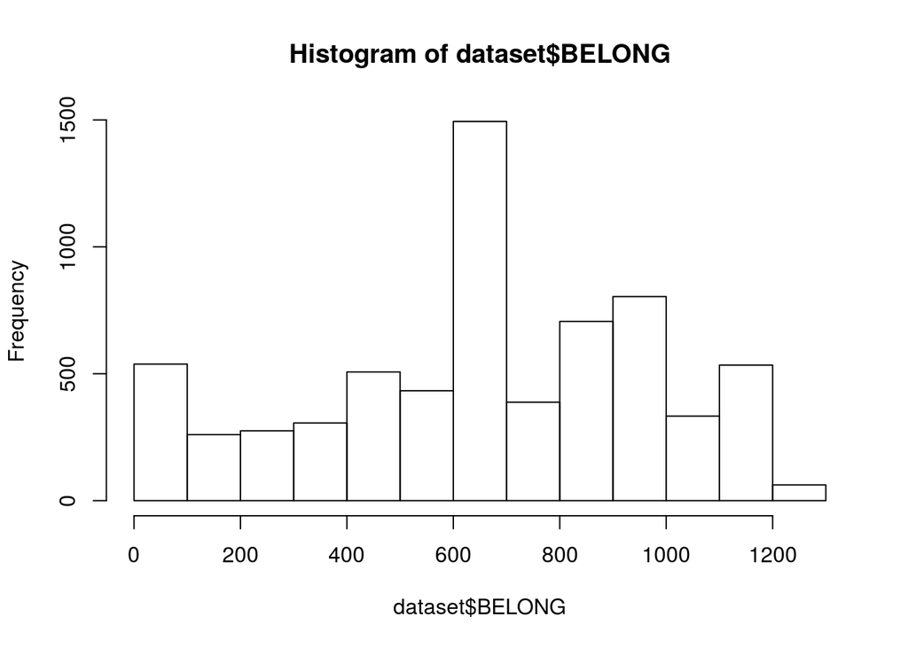

```r
#exploraciÃ³n de datos
hist(dataset$BELONG, xlim = c(0,1300)) #distribuciÃ³n variable dependiente a nivel estudiante
```

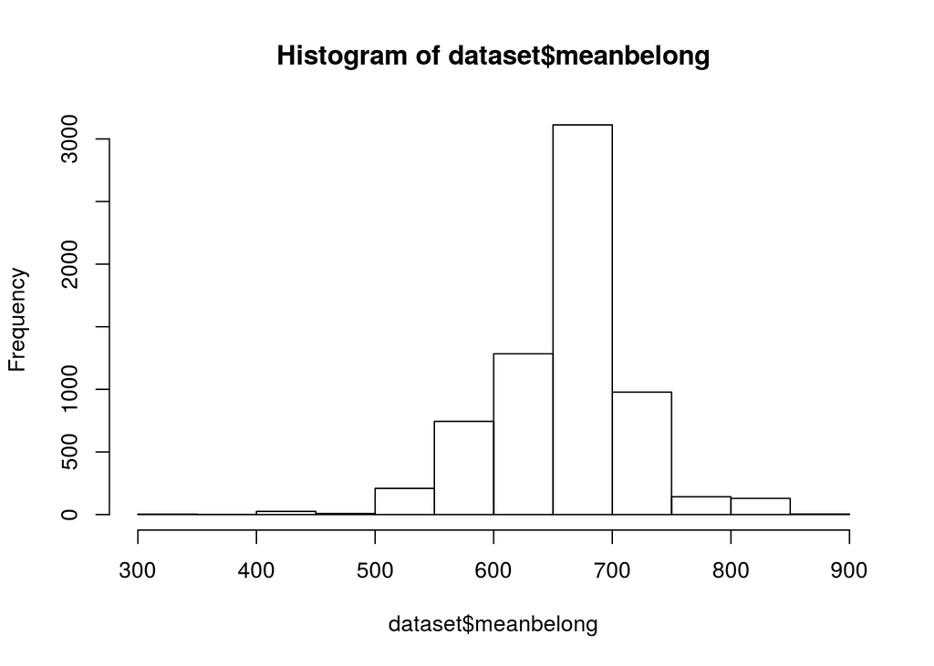

```r
#histograma de BELONG por escuela
dataset <- dataset %>%
  group_by(CNTSCHID) %>%
  mutate(meanbelong = mean(BELONG))
hist(dataset$meanbelong)
```

```r
#matriz de correlaciones
cormat=dataset %>% select(BELONG,ST004D01T,MOTIVAT,COOPERATE,fairteacher,ESCS,SCHSIZE,m_gen,m_escs) %>% cor()
round(cormat, digits=2)
```

```
##             CNTSCHID BELONG ST004D01T MOTIVAT COOPERATE fairteacher  ESCS
## CNTSCHID        1.00  -0.02     -0.02    0.00      0.01        0.01 -0.01
## BELONG         -0.02   1.00     -0.03    0.02      0.03        0.04 -0.01
## ST004D01T      -0.02  -0.03      1.00    0.02      0.00       -0.10  0.00
## MOTIVAT         0.00   0.02      0.02    1.00      0.01        0.02 -0.02
## COOPERATE       0.01   0.03      0.00    0.01      1.00        0.04  0.00
## fairteacher     0.01   0.04     -0.10    0.02      0.04        1.00  0.00
## ESCS           -0.01  -0.01      0.00   -0.02      0.00        0.00  1.00
## SCHSIZE         0.13  -0.01      0.01   -0.01      0.00        0.02  0.00
## m_gen          -0.05  -0.02      0.41   -0.01      0.00       -0.04  0.00
## m_escs         -0.02  -0.01      0.00    0.01      0.01        0.03  0.22
##             SCHSIZE m_gen m_escs
## CNTSCHID       0.13 -0.05  -0.02
## BELONG        -0.01 -0.02  -0.01
## ST004D01T      0.01  0.41   0.00
## MOTIVAT       -0.01 -0.01   0.01
## COOPERATE      0.00  0.00   0.01
## fairteacher    0.02 -0.04   0.03
## ESCS           0.00  0.00   0.22
## SCHSIZE        1.00  0.03  -0.01
## m_gen          0.03  1.00   0.00
## m_escs        -0.01  0.00   1.00
```

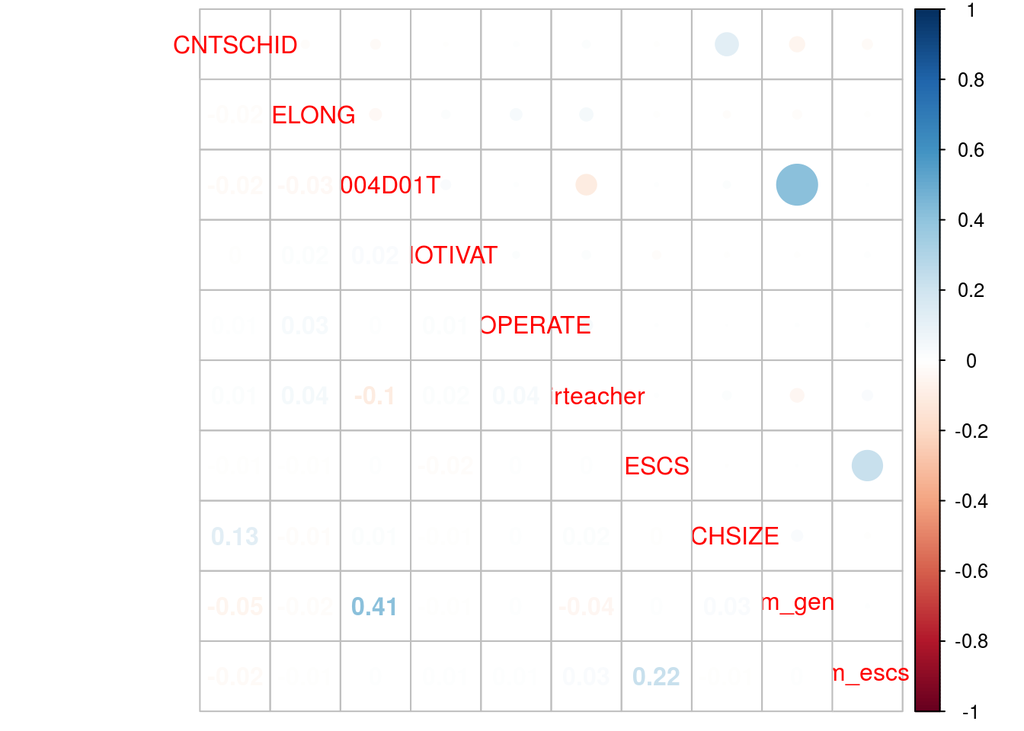

```r
corrplot.mixed(cormat)
```

*3. Resultados: Aplicación de modelos* **3.1 Modelos de regresión de mínimos cuadrados de nivel uno**

```r
reg<- lm(BELONG~ST004D01T+MOTIVAT+COOPERATE+fairteacher+ESCS+SCHSIZE+m_gen+m_escs, data=dataset)
stargazer(reg, title = "RegresiÃ³n datos individuales", type='text')
```

```
##
## RegresiÃ³n datos individuales
## ===============================================
##                         Dependent variable:
##                     ---------------------------
##                               BELONG
## -----------------------------------------------
## ST004D01T                    -17.220**
##                               (8.622)
##
## MOTIVAT                        0.036
##                               (0.028)
##
## COOPERATE                     0.150**
##                               (0.060)
##
## fairteacher                  3.728***
##                               (1.248)
##
## ESCS                          -0.001
##                               (0.002)
##
## SCHSIZE                       -0.006
##                               (0.006)
##
## m_gen                         -9.438
##                              (20.937)
##
## m_escs                        -0.005
##                               (0.010)
##
## Constant                    633.766***
##                              (47.332)
##
## -----------------------------------------------
## Observations                   6,640
## R2                             0.004
## Adjusted R2                    0.003
## Residual Std. Error     318.870 (df = 6631)
## F Statistic           3.303*** (df = 8; 6631)
## ===============================================
## Note:               *p<0.1; **p<0.05; ***p<0.01
```

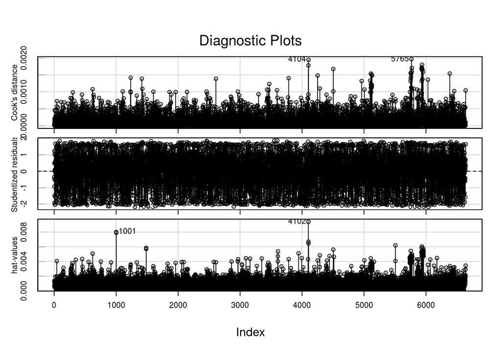

```r
#EvaluaciÃ³n de residuos
influenceIndexPlot(reg, vars=c("Cook", "Studentized", "hat"), id.n=5)
```

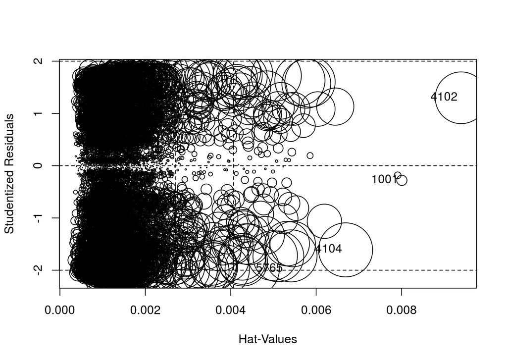

```
##         StudRes          Hat        CookD
## 1001 -0.2803776 0.0080063697 7.050685e-05
## 1303 -2.1727683 0.0009741721 5.112103e-04
## 4102  1.2995817 0.0093943127 1.779442e-03
## 4104 -1.6111534 0.0066890578 1.941809e-03
## 5765 -1.9760540 0.0045027471 1.961564e-03
## 6038 -2.1815588 0.0009105816 4.816812e-04
```

```r
influencePlot(reg, id.n=3)
```

```r
#RegresiÃ³n por casos agrupados en escuelas
agg_dataset=dataset %>% group_by(CNTSCHID) %>% summarise_all(funs(mean)) %>% as.data.frame()
stargazer(agg_dataset, type = "text") #agrupar casos por escuela y visualizar descriptivos
```

```
##
## =========================================================================================
## Statistic      N       Mean      St. Dev.    Min       Pctl(25)     Pctl(75)      Max
## -----------------------------------------------------------------------------------------
## CNTSCHID      214 15,200,115.000  67.242  15,200,001 15,200,056.0 15,200,173.0 15,200,232
## BELONG        214    648.551      80.924   313.000     617.611      689.269     857.750
## ST004D01T     214     1.529       0.226     1.000       1.426        1.614       2.000
## MOTIVAT       214    262.406      41.902    58.000     241.837      276.573     497.000
## COOPERATE     214    159.260      16.769      93        150.9        169.5        216
## unfairteacher 214     9.170       1.367     6.000       8.545        9.470       21.000
## ESCS          214   3,164.104    589.874   286.000    2,877.266    3,462.481   5,266.000
## SCHSIZE       214    900.467     641.032      30        453.2       1,174.8      4,052
## fairteacher   214     14.830      1.367     3.000       14.530       15.455      18.000
## m_gen         214     1.529       0.226     1.000       1.426        1.614       2.000
## m_escs        214   3,164.104    589.874   286.000    2,877.266    3,462.481   5,266.000
## meanbelong    214    648.551      80.924   313.000     617.611      689.269     857.750
## -----------------------------------------------------------------------------------------
```

```r
reg_agg<- lm(BELONG~ST004D01T+MOTIVAT+COOPERATE+fairteacher+ESCS+SCHSIZE+m_gen+m_escs, data=agg_dataset) #regresiÃ³n

#Comparar regresiones
stargazer(reg,reg_agg, title = "ComparaciÃ³n de modelos",column.labels=c("Individual","Agregado"), type ='text')
```

```
##
## ComparaciÃ³n de modelos
## ==================================================================
##                                  Dependent variable:
##                     ----------------------------------------------
##                                         BELONG
##                           Individual               Agregado
##                               (1)                    (2)
## ------------------------------------------------------------------
## ST004D01T                  -17.220**              -88.859***
##                             (8.622)                (24.651)
##
## MOTIVAT                      0.036                -0.347***
##                             (0.028)                (0.130)
##
## COOPERATE                   0.150**                 0.134
##                             (0.060)                (0.323)
##
## fairteacher                3.728***                 -2.697
##                             (1.248)                (4.185)
##
## ESCS                        -0.001                  -0.008
##                             (0.002)                (0.009)
##
## SCHSIZE                     -0.006                  0.009
##                             (0.006)                (0.008)
##
## m_gen                       -9.438
##                            (20.937)
##
## m_escs                      -0.005
##                             (0.010)
##
## Constant                  633.766***              912.159***
##                            (47.332)                (96.198)
##
## ------------------------------------------------------------------
## Observations                 6,640                   214
## R2                           0.004                  0.120
## Adjusted R2                  0.003                  0.095
## Residual Std. Error   318.870 (df = 6631)     77.001 (df = 207)
## F Statistic         3.303*** (df = 8; 6631) 4.709*** (df = 6; 207)
## ==================================================================
## Note:                                  *p<0.1; **p<0.05; ***p<0.01
```

**3.2 Modelos multinivel**

```r
#modelo nulo
model0 <- lmer(BELONG ~ 1 + (1|CNTSCHID), data=dataset, REML=FALSE)
screenreg(model0)
```

```
##
## ========================================
##                            Model 1
## ----------------------------------------
## (Intercept)                   658.62 ***
##                                (4.03)
## ----------------------------------------
## AIC                         95422.92
## BIC                         95443.33
## Log Likelihood             -47708.46
## Num. obs.                    6640
## Num. groups: CNTSCHID         214
## Var: CNTSCHID (Intercept)     164.14
## Var: Residual              101780.46
## ========================================
## *** p < 0.001, ** p < 0.01, * p < 0.05
```

```r
reghelper::ICC(model0) #calculo correlaciÃ³n intraclase modelo nulo (ICC)
```

```
## [1] 0.001610062
```

**3.3 Modelos con variables de nivel 1**

```r
#Modelos con variables nivel 1
model1 <- lmer(BELONG ~ 1 + ST004D01T+(1|CNTSCHID), data=dataset, REML=FALSE)
screenreg(model1)
```

```
##
## ========================================
##                            Model 1
## ----------------------------------------
## (Intercept)                   690.14 ***
##                               (12.48)
## ST004D01T                     -20.96 **
##                                (7.86)
## ----------------------------------------
## AIC                         95417.82
## BIC                         95445.02
## Log Likelihood             -47704.91
## Num. obs.                    6640
## Num. groups: CNTSCHID         214
## Var: CNTSCHID (Intercept)     137.38
## Var: Residual              101696.93
## ========================================
## *** p < 0.001, ** p < 0.01, * p < 0.05
```

```r
anova(model0,model1) #comparaciÃ³n modelos
```

```
## Data: dataset
## Models:
## model0: BELONG ~ 1 + (1 | CNTSCHID)
## model1: BELONG ~ 1 + ST004D01T + (1 | CNTSCHID)
##        Df   AIC   BIC logLik deviance Chisq Chi Df Pr(>Chisq)
## model0  3 95423 95443 -47708    95417
## model1  4 95418 95445 -47705    95410 7.103      1   0.007696 **
## ---
## Signif. codes:  0 '***' 0.001 '**' 0.01 '*' 0.05 '.' 0.1 ' ' 1
```

```r
model2 <- lmer(BELONG ~ 1 + ST004D01T+ESCS+(1|CNTSCHID), data=dataset, REML=FALSE)
screenreg(model2)
```

```
##
## ========================================
##                            Model 1
## ----------------------------------------
## (Intercept)                   694.00 ***
##                               (14.13)
## ST004D01T                     -20.94 **
##                                (7.86)
## ESCS                           -0.00
##                                (0.00)
## ----------------------------------------
## AIC                         95419.48
## BIC                         95453.49
## Log Likelihood             -47704.74
## Num. obs.                    6640
## Num. groups: CNTSCHID         214
## Var: CNTSCHID (Intercept)     135.64
## Var: Residual              101693.40
## ========================================
## *** p < 0.001, ** p < 0.01, * p < 0.05
```

```r
anova(model0,model1,model2)
```

```
## Data: dataset
## Models:
## model0: BELONG ~ 1 + (1 | CNTSCHID)
## model1: BELONG ~ 1 + ST004D01T + (1 | CNTSCHID)
## model2: BELONG ~ 1 + ST004D01T + ESCS + (1 | CNTSCHID)
##        Df   AIC   BIC logLik deviance  Chisq Chi Df Pr(>Chisq)
## model0  3 95423 95443 -47708    95417
## model1  4 95418 95445 -47705    95410 7.1030      1   0.007696 **
## model2  5 95419 95453 -47705    95409 0.3386      1   0.560634
## ---
## Signif. codes:  0 '***' 0.001 '**' 0.01 '*' 0.05 '.' 0.1 ' ' 1
```

```r
model3 <- lmer(BELONG ~ 1 + ST004D01T+ESCS+MOTIVAT+(1|CNTSCHID), data=dataset, REML=FALSE)
screenreg(model3)
```

```
##
## ========================================
##                            Model 1
## ----------------------------------------
## (Intercept)                   684.03 ***
##                               (15.88)
## ST004D01T                     -21.18 **
##                                (7.86)
## ESCS                           -0.00
##                                (0.00)
## MOTIVAT                         0.04
##                                (0.03)
## ----------------------------------------
## AIC                         95419.59
## BIC                         95460.40
## Log Likelihood             -47703.80
## Num. obs.                    6640
## Num. groups: CNTSCHID         214
## Var: CNTSCHID (Intercept)     143.24
## Var: Residual              101657.18
## ========================================
## *** p < 0.001, ** p < 0.01, * p < 0.05
```

```r
anova(model0,model1,model2,model3)
```

```
## Data: dataset
## Models:
## model0: BELONG ~ 1 + (1 | CNTSCHID)
## model1: BELONG ~ 1 + ST004D01T + (1 | CNTSCHID)
## model2: BELONG ~ 1 + ST004D01T + ESCS + (1 | CNTSCHID)
## model3: BELONG ~ 1 + ST004D01T + ESCS + MOTIVAT + (1 | CNTSCHID)
##        Df   AIC   BIC logLik deviance  Chisq Chi Df Pr(>Chisq)
## model0  3 95423 95443 -47708    95417
## model1  4 95418 95445 -47705    95410 7.1030      1   0.007696 **
## model2  5 95419 95453 -47705    95409 0.3386      1   0.560634
## model3  6 95420 95460 -47704    95408 1.8887      1   0.169345
## ---
## Signif. codes:  0 '***' 0.001 '**' 0.01 '*' 0.05 '.' 0.1 ' ' 1
```

```r
model4 <- lmer(BELONG ~ 1 + ST004D01T+ESCS+MOTIVAT+fairteacher+(1|CNTSCHID), data=dataset, REML=FALSE)
screenreg(model4)
```

```
##
## ========================================
##                            Model 1
## ----------------------------------------
## (Intercept)                   623.36 ***
##                               (25.34)
## ST004D01T                     -18.70 *
##                                (7.90)
## ESCS                           -0.00
##                                (0.00)
## MOTIVAT                         0.04
##                                (0.03)
## fairteacher                     3.83 **
##                                (1.25)
## ----------------------------------------
## AIC                         95412.19
## BIC                         95459.79
## Log Likelihood             -47699.09
## Num. obs.                    6640
## Num. groups: CNTSCHID         214
## Var: CNTSCHID (Intercept)     172.83
## Var: Residual              101485.00
## ========================================
## *** p < 0.001, ** p < 0.01, * p < 0.05
```

```r
anova(model0,model1,model2,model3,model4)
```

```
## Data: dataset
## Models:
## model0: BELONG ~ 1 + (1 | CNTSCHID)
## model1: BELONG ~ 1 + ST004D01T + (1 | CNTSCHID)
## model2: BELONG ~ 1 + ST004D01T + ESCS + (1 | CNTSCHID)
## model3: BELONG ~ 1 + ST004D01T + ESCS + MOTIVAT + (1 | CNTSCHID)
## model4: BELONG ~ 1 + ST004D01T + ESCS + MOTIVAT + fairteacher + (1 |
## model4:     CNTSCHID)
##        Df   AIC   BIC logLik deviance  Chisq Chi Df Pr(>Chisq)
## model0  3 95423 95443 -47708    95417
## model1  4 95418 95445 -47705    95410 7.1030      1   0.007696 **
## model2  5 95419 95453 -47705    95409 0.3386      1   0.560634
## model3  6 95420 95460 -47704    95408 1.8887      1   0.169345
## model4  7 95412 95460 -47699    95398 9.4067      1   0.002162 **
## ---
## Signif. codes:  0 '***' 0.001 '**' 0.01 '*' 0.05 '.' 0.1 ' ' 1
```

```r
model5 <- lmer(BELONG ~ 1 + ST004D01T+ESCS+MOTIVAT+fairteacher+COOPERATE+(1|CNTSCHID), data=dataset, REML=FALSE)
screenreg(model5)
```

```
##
## ========================================
##                            Model 1
## ----------------------------------------
## (Intercept)                   601.47 ***
##                               (26.78)
## ST004D01T                     -18.86 *
##                                (7.90)
## ESCS                           -0.00
##                                (0.00)
## MOTIVAT                         0.04
##                                (0.03)
## fairteacher                     3.71 **
##                                (1.25)
## COOPERATE                       0.15 *
##                                (0.06)
## ----------------------------------------
## AIC                         95407.86
## BIC                         95462.27
## Log Likelihood             -47695.93
## Num. obs.                    6640
## Num. groups: CNTSCHID         214
## Var: CNTSCHID (Intercept)     172.69
## Var: Residual              101388.36
## ========================================
## *** p < 0.001, ** p < 0.01, * p < 0.05
```

```r
anova(model0,model1,model2,model3,model4,model5)
```

```
## Data: dataset
## Models:
## model0: BELONG ~ 1 + (1 | CNTSCHID)
## model1: BELONG ~ 1 + ST004D01T + (1 | CNTSCHID)
## model2: BELONG ~ 1 + ST004D01T + ESCS + (1 | CNTSCHID)
## model3: BELONG ~ 1 + ST004D01T + ESCS + MOTIVAT + (1 | CNTSCHID)
## model4: BELONG ~ 1 + ST004D01T + ESCS + MOTIVAT + fairteacher + (1 |
## model4:     CNTSCHID)
## model5: BELONG ~ 1 + ST004D01T + ESCS + MOTIVAT + fairteacher + COOPERATE +
## model5:     (1 | CNTSCHID)
##        Df   AIC   BIC logLik deviance  Chisq Chi Df Pr(>Chisq)
## model0  3 95423 95443 -47708    95417
## model1  4 95418 95445 -47705    95410 7.1030      1   0.007696 **
## model2  5 95419 95453 -47705    95409 0.3386      1   0.560634
## model3  6 95420 95460 -47704    95408 1.8887      1   0.169345
## model4  7 95412 95460 -47699    95398 9.4067      1   0.002162 **
## model5  8 95408 95462 -47696    95392 6.3248      1   0.011906 *
## ---
## Signif. codes:  0 '***' 0.001 '**' 0.01 '*' 0.05 '.' 0.1 ' ' 1
```

**3.4 Modelos con variables de nivel 2**

```r
model6 = lmer(BELONG ~ 1 + SCHSIZE + m_escs + m_gen+(1 | CNTSCHID), data = dataset)
screenreg(model6)
```

```
##
## ========================================
##                            Model 1
## ----------------------------------------
## (Intercept)                   723.64 ***
##                               (43.07)
## SCHSIZE                        -0.01
##                                (0.01)
## m_escs                         -0.00
##                                (0.01)
## m_gen                         -29.39
##                               (19.68)
## ----------------------------------------
## AIC                         95428.92
## BIC                         95469.73
## Log Likelihood             -47708.46
## Num. obs.                    6640
## Num. groups: CNTSCHID         214
## Var: CNTSCHID (Intercept)     172.54
## Var: Residual              101783.49
## ========================================
## *** p < 0.001, ** p < 0.01, * p < 0.05
```

```r
anova(model5,model6)
```

```
## refitting model(s) with ML (instead of REML)
```

```
## Data: dataset
## Models:
## model6: BELONG ~ 1 + SCHSIZE + m_escs + m_gen + (1 | CNTSCHID)
## model5: BELONG ~ 1 + ST004D01T + ESCS + MOTIVAT + fairteacher + COOPERATE +
## model5:     (1 | CNTSCHID)
##        Df   AIC   BIC logLik deviance  Chisq Chi Df Pr(>Chisq)
## model6  6 95426 95466 -47707    95414
## model5  8 95408 95462 -47696    95392 21.735      2  1.907e-05 ***
## ---
## Signif. codes:  0 '***' 0.001 '**' 0.01 '*' 0.05 '.' 0.1 ' ' 1
```

**3.5 Modelo multinivel intercepto aleatorio.**

```r
model7 <- lmer(BELONG ~ 1 + ST004D01T+ESCS+MOTIVAT+fairteacher+COOPERATE+SCHSIZE+m_escs+m_gen+(1|CNTSCHID), data=dataset, REML=FALSE)
screenreg(model7)
```

```
##
## ========================================
##                            Model 1
## ----------------------------------------
## (Intercept)                   633.32 ***
##                               (48.16)
## ST004D01T                     -17.21 *
##                                (8.61)
## ESCS                           -0.00
##                                (0.00)
## MOTIVAT                         0.04
##                                (0.03)
## fairteacher                     3.75 **
##                                (1.25)
## COOPERATE                       0.15 *
##                                (0.06)
## SCHSIZE                        -0.01
##                                (0.01)
## m_escs                         -0.00
##                                (0.01)
## m_gen                          -9.58
##                               (21.35)
## ----------------------------------------
## AIC                         95412.58
## BIC                         95487.39
## Log Likelihood             -47695.29
## Num. obs.                    6640
## Num. groups: CNTSCHID         214
## Var: CNTSCHID (Intercept)     145.39
## Var: Residual              101394.61
## ========================================
## *** p < 0.001, ** p < 0.01, * p < 0.05
```

**3.6 modelo multinivel pendiente aleatoria.**

```r
model8 <- lmer(BELONG ~ 1 + ST004D01T+ESCS+MOTIVAT+fairteacher+COOPERATE+SCHSIZE+m_escs+m_gen+(1+ESCS|CNTSCHID), data=dataset, REML=FALSE)
```

```
## boundary (singular) fit: see ?isSingular
```

```r
screenreg(model8)
```

```
##
## =============================================
##                                 Model 1
## ---------------------------------------------
## (Intercept)                        632.42 ***
##                                    (48.63)
## ST004D01T                          -17.66 *
##                                     (8.62)
## ESCS                                -0.00
##                                     (0.00)
## MOTIVAT                              0.03
##                                     (0.03)
## fairteacher                          3.66 **
##                                     (1.25)
## COOPERATE                            0.14 *
##                                     (0.06)
## SCHSIZE                             -0.01
##                                     (0.01)
## m_escs                              -0.00
##                                     (0.01)
## m_gen                              -11.15
##                                    (21.38)
## ---------------------------------------------
## AIC                              95478.43
## BIC                              95566.84
## Log Likelihood                  -47726.21
## Num. obs.                         6640
## Num. groups: CNTSCHID              214
## Var: CNTSCHID (Intercept)         8576.91
## Var: CNTSCHID ESCS                   0.00
## Cov: CNTSCHID (Intercept) ESCS      -3.09
## Var: Residual                    99979.79
## =============================================
## *** p < 0.001, ** p < 0.01, * p < 0.05
```

```r
screenreg(list(model5, model6, model7,model8)) #comparaciÃ³n modelos nivel 1, nivel 2, multinivel interceptos aleatorios y multi pendiente aleatoria.
```

```
##
## ==========================================================================================
##                                 Model 1        Model 2        Model 3        Model 4
## ------------------------------------------------------------------------------------------
## (Intercept)                        601.47 ***     723.64 ***     633.32 ***     632.42 ***
##                                    (26.78)        (43.07)        (48.16)        (48.63)
## ST004D01T                          -18.86 *                      -17.21 *       -17.66 *
##                                     (7.90)                        (8.61)         (8.62)
## ESCS                                -0.00                         -0.00          -0.00
##                                     (0.00)                        (0.00)         (0.00)
## MOTIVAT                              0.04                          0.04           0.03
##                                     (0.03)                        (0.03)         (0.03)
## fairteacher                          3.71 **                       3.75 **        3.66 **
##                                     (1.25)                        (1.25)         (1.25)
## COOPERATE                            0.15 *                        0.15 *         0.14 *
##                                     (0.06)                        (0.06)         (0.06)
## SCHSIZE                                            -0.01          -0.01          -0.01
##                                                    (0.01)         (0.01)         (0.01)
## m_escs                                             -0.00          -0.00          -0.00
##                                                    (0.01)         (0.01)         (0.01)
## m_gen                                             -29.39          -9.58         -11.15
##                                                   (19.68)        (21.35)        (21.38)
## ------------------------------------------------------------------------------------------
## AIC                              95407.86       95428.92       95412.58       95478.43
## BIC                              95462.27       95469.73       95487.39       95566.84
## Log Likelihood                  -47695.93      -47708.46      -47695.29      -47726.21
## Num. obs.                         6640           6640           6640           6640
## Num. groups: CNTSCHID              214            214            214            214
## Var: CNTSCHID (Intercept)          172.69         172.54         145.39        8576.91
## Var: Residual                   101388.36      101783.49      101394.61       99979.79
## Var: CNTSCHID ESCS                                                                0.00
## Cov: CNTSCHID (Intercept) ESCS                                                   -3.09
## ==========================================================================================
## *** p < 0.001, ** p < 0.01, * p < 0.05
```

*4 Conclusiones*

Las conclusiones se realizarán en la entrega definitiva con todos los modelos listos y las herramientas necesarias para corroborar o descartar las hipótesis.